# SEE_day0_clean

### 检查工作环境，查看文件列表

```r
list.files("../../../Data/raw/day0/phase_015/jsPsych",pattern = "\\.csv$", full.names = TRUE)
```

```
 [1] "../../../Data/raw/day0/phase_015/jsPsych/jsPsych_26_803277758196228098_jsPsych.csv"
 [2] "../../../Data/raw/day0/phase_015/jsPsych/jsPsych_SDASD_803277648590802945_jsPsych.csv"
 [3] "../../../Data/raw/day0/phase_015/jsPsych/jsPsych_sponsor_803274583749828610_jsPsych.csv"
 [4] "../../../Data/raw/day0/phase_015/jsPsych/jsPsych_wcn_psy_799258842323099650_jsPsych.csv"
 [5] "../../../Data/raw/day0/phase_015/jsPsych/jsPsych_wuyu_803272732757336066_jsPsych.csv"
 [6] "../../../Data/raw/day0/phase_015/jsPsych/jsPsych_阿楠_803282575434190849_jsPsych.csv"
 [7] "../../../Data/raw/day0/phase_015/jsPsych/jsPsych_谙雎_803275848370233345_jsPsych.csv"
 [8] "../../../Data/raw/day0/phase_015/jsPsych/jsPsych_大鱼_803275130234212353_jsPsych.csv"
 [9] "../../../Data/raw/day0/phase_015/jsPsych/jsPsych_郭1_803274922729283586_jsPsych.csv"
[10] "../../../Data/raw/day0/phase_015/jsPsych/jsPsych_郭咯_803275106024689665_jsPsych.csv"
[11] "../../../Data/raw/day0/phase_015/jsPsych/jsPsych_哈哈啊哈哈_803284109672718338_jsPsych.csv"
[12] "../../../Data/raw/day0/phase_015/jsPsych/jsPsych_黑天_803282086113976322_jsPsych.csv"
[13] "../../../Data/raw/day0/phase_015/jsPsych/jsPsych_柯炫_803276217196482561_jsPsych.csv"
[14] "../../../Data/raw/day0/phase_015/jsPsych/jsPsych_可东_803281249186877442_jsPsych.csv"
[15] "../../../Data/raw/day0/phase_015/jsPsych/jsPsych_黎兴_803282279433768962_jsPsych.csv"
```

[output cut: 31 more lines]

### Prepare clean data for variables.

##先在../../../Data/clean/clean_day0/建立子文件phase_00x

```r
# 处理 day0 的function

##记录单个被试人口学信息
day0_process<-function(phase){

  day0<-read.csv(paste0("../../../Data/raw/day0/",phase,"/day0_",phase,".csv"),fileEncoding = 'UTF-8')

    #创建子文件夹"../../../Data/clean/clean_day0/phase"用于储存清洗后的文件

dir.create(paste0("../../../Data/clean/clean_day0/",phase), recursive = TRUE)

## 记录被试 day0 完成所有问卷的数据，宽数据版
day0_all <- day0 %>%
  filter(trial_index == 0) %>%  #选择第一行
  select(subj_idx, ParticipantID,everything(), -c("rt", "stimulus", "response", "trial_type", "trial_index", "time_elapsed", "internal_node_id", "success","user_agent","accuracy","question_order","responses","item_order","radio_event_ids","radio_event_times","key_event_times","mouse_event_times","straightlining","zigzagging","honeypot","value"))%>%  #选择列
  arrange(ParticipantID)%>%  #按ParticipantID从低到高排序
  mutate(ID = paste0(phase,"_subj_", row_number()))%>% #生成新列ID
   arrange(subj_idx)

  output_path <- paste0("../../../Data/clean/clean_day0/",phase,"/day0_all_",phase, ".csv") #文件的输出路径
  write.csv(day0_all,output_path)
}

## 运行范例，每次运行仅需要修改批次号"phase_002"
day0_process("phase_015")
```

```r
subj_phase_day0 <- function(phase,Eligible,Moneny,Paid_date) {

# 导入文件，修改文件地址“/phase_00x/day0_all_phase_00x.csv”中的批次号“phase_00x”
day0_all<-read.csv(paste0("../../../Data/clean/clean_day0/",phase,"/day0_all_",phase,".csv"), header = TRUE, sep = ",", stringsAsFactors = FALSE, fileEncoding = "UTF-8") %>%
  rename(No=X)#重命名列


# 导入文件，修改文件地址"../../../Data/raw/day0/phase_00x/"中的批次号“phase_00x”
subj_day0<-read.csv(list.files(paste0("../../../Data/raw/day0/",phase,"/"),pattern = "^SEE.*\\.csv$", full.names = TRUE), header = TRUE, sep = ",", stringsAsFactors = FALSE, fileEncoding = "UTF-8")%>%
    slice(-1)%>%
  select(-c("Subject.IDs","NodeId","X"))%>%#去除这些列
  rename(
    USERID=UserId,#脑岛ID
    Time_day0=Time,#实验时间
    religion=Info_Q1,#宗教
    e_mail = Info_Q2,#邮箱
    wechat = Info_Q3,#微信
    region = Info_Q4,#地区
    major = Info_Q5,#专业
    left_hand = Info_Q6,#是否左撇子
    refresh_rate = Info_Q7,#刷新率
    resolution_ratio = Info_Q8#电脑分辨率
  ) %>%
  mutate(Eligible=Eligible,#是否符合要求
         Moneny=Moneny,#报酬金额
         Paid_date=Paid_date)%>%#付偿日期
  arrange( USERID)%>%#将脑岛ID从低到高排序
  mutate(No= row_number())%>%#按行依次编号
merge(.,day0_all[, c("No", "ID","ParticipantID","subj_idx")], by = "No", all.x = TRUE)#将ID合并进文件

# 导出文件，输出的文件地址"../../../Data/raw/day0/phase_00x/subj_day0_phase_00x.xlsx",修改批次号“phase_00x”
write.xlsx(subj_day0, file=paste0("../../../Data/raw/day0/",phase,"/subj_day0_",phase,".xlsx"))

#subj_day0_phase_003<-read.xlsx("../../../Data/raw/day0/phase_003/subj_day0_phase_003.xlsx")
subj_email<-subj_day0%>%
  select(c("ID","e_mail","wechat","Subject.Name","region"))%>%
  rename(姓名=ID,
   邮件地址=e_mail,
         移动电话=wechat,
         联系地址=region
         )

write.csv(subj_email, paste0("../../../Data/raw/day0/",phase,"/subj_email_",phase,".csv"))

#去掉该数据中的被试脑岛编号和被试姓名
day0_all<-day0_all%>%
select(-c("subj_name","subj_idx"))
write.csv(day0_all,paste0("../../../Data/clean/clean_day0/",phase,"/day0_all_",phase,".csv"))

}

subj_phase_day0("phase_015","yes","1","1.26 ")
```

# day0 记录人口统计学信息，自我概念清晰度，焦虑，抑郁

## income_scale = [“A.无收入”, “B.2000 元以下”, “C.2000—5000 元”, “D.5000—10000 元”, “E.10000—30000 元”, “F.30000—50000 元”, “G.50000—100000 元”,“H.100000—150000 元”, “I.150000—200000元”, “J.200000 元以上”];

## phq 0、1、2、3分值。PHQ-9总分值范围从0～27分。分值5、10、15、20分别相对应代表轻、中、中重、重度抑郁分界值。

## gad 0、1、2、3分。ＧＡＤ－7总分范围为0～21分。分值 5、10、15分别对应代表“轻度”、“中度”、“重度”焦虑程度分界值。国外大规模样本研究显示当分 界值取10分时，ＧＡＤ－7的敏感度和特异度最佳，分别为89％和82%

## selfclarity 该量表使用 5 点计分法，1 表示“完全不符”，5 表示“完全符合”，共 12 题，其中 6、11 采用正向计分题，其余题目均需反向计分[js代码中已经反向计分]。最终总分越高说明自我概念清晰性越高。

```r
plot_descript_day0<-function(phase){

  day0_subj<-read.xlsx(paste0("../../../Data/raw/day0/",phase,"/subj_day0_",phase,".xlsx"))  # 参加day0实验的所有被试

day0_all<-read.csv(paste0("../../../Data/clean/clean_day0/",phase,"/day0_all_",phase,".csv"), fileEncoding = "UTF-8")  # day0问卷数据

invalid_day0<-day0_all%>%
  filter(age>59|age<18)%>%
print()  ## day0中年龄小于18或大于59岁

write.xlsx(invalid_day0, file = paste0("../../../Data/raw/day0/", phase, "/invalid_day0_", phase, ".xlsx"))  ##输出无效被试

day0_subj<-day0_subj%>%
  filter(!ID %in% invalid_day0$ID)

write.xlsx(day0_subj, file=paste0("../../../Data/raw/day0/",phase,"/subj_day0_",phase,".xlsx"))  ## 输出参加day0符合条件的被试

day0_all <- day0_all %>%
   filter(age<=59&age>=18)%>%
  select(-birthday,-ID,No,ParticipantID)%>%
  mutate(
    age=case_when(
          between(age, 18, 28) ~ "18~28",
          between(age, 28, 38) ~ "28~38",
           between(age, 38, 48) ~ "38~48",
          between(age, 48, 59) ~ "48~59",
          age>59~ ">59",
          TRUE ~ as.character(age)
        ),
         obj_ses1=as.character(obj_ses1),
         fri_ses2=as.character(fri_ses2),
        sex=case_when(
          sex==0~"male",
          sex==1~"female",
          TRUE ~ as.character(sex)
        ) ) %>%
 mutate(fatherEdu = case_when(
    fatherEdu == 0 ~ "zero",
    fatherEdu == 1 ~ "elementary",
    fatherEdu == 2 ~ "junior",
    fatherEdu == 3 ~ "senior",
    fatherEdu == 4 ~ "college",
    fatherEdu == 5 ~ "graduate",
    TRUE ~ as.character(fatherEdu)  # 如果没有匹配到上述条件，保持不变
  ))%>%
  mutate(motherEdu = case_when(
    motherEdu == 0 ~ "zero",#没上学
    motherEdu == 1 ~ "elementary",#小学
    motherEdu == 2 ~ "junior",#初中
    motherEdu == 3 ~ "senior",#高中，中专
    motherEdu == 4 ~ "college",#大学（专科或本科）
    motherEdu == 5 ~ "graduate",#研究生
    TRUE ~ as.character(motherEdu)  # 如果没有匹配到上述条件，保持不变
  ))%>%
  mutate(FatherOccupation = case_when(
    FatherOccupation == 0 ~ "临时工",
    FatherOccupation == 1 ~ "个体经营",
    FatherOccupation == 2 ~ "一般管理",
    FatherOccupation == 3 ~ "中层管理",
    FatherOccupation == 4 ~ "高级管理",
    TRUE ~ as.character(FatherOccupation)  # 如果没有匹配到上述条件，保持不变
  ))%>%
  mutate(MotherOccupation = case_when(
    MotherOccupation == 0 ~ "临时工",
    MotherOccupation == 1 ~ "个体经营",
    MotherOccupation == 2 ~ "一般管理",
    MotherOccupation == 3 ~ "中层管理",
    MotherOccupation == 4 ~ "高级管理",
    TRUE ~ as.character(MotherOccupation)  # 如果没有匹配到上述条件，保持不变
  ))%>%
  mutate(income = case_when(
    income == 0 ~ "zero",
    income < 2000 ~ "<2000",
    between(income, 2000, 5000) ~ "2000~5000",
    between(income, 5000, 10000) ~ "5000~10000",
    between(income, 10000, 30000) ~ "10000~30000",
    between(income, 30000, 50000) ~ "30000~50000",
    between(income, 50000, 100000) ~ "50000~100000",
    between(income, 100000, 150000) ~ "100000~150000",
    between(income, 150000, 200000) ~ "150000~200000",
    income >= 200000 ~ "≥200000",
    TRUE ~ as.character(income)  # 如果没有匹配的条件，保持不变
  ))%>%
  mutate(phq_al = rowSums(select(., starts_with("phq_")))) %>%
  mutate(phq = case_when(
    phq_al >= 0 & phq_al <= 4 ~ "none",
    phq_al >= 5 & phq_al <= 9 ~ "mild",
    phq_al >= 10 & phq_al <= 14 ~ "moderate",
    phq_al >= 15 & phq_al <= 19 ~ "mod to severe",
     phq_al >= 20  ~ "severe",
    TRUE ~ NA_character_
  ))%>%
mutate(selfclarity_al = rowSums(select(., starts_with("selfclarity_")))) %>%
mutate(gad_al = rowSums(select(., starts_with("gad_")))) %>%
  mutate(gad = case_when(
    gad_al >= 0 & gad_al <= 4 ~ "none",
    gad_al >= 5 & gad_al <= 9 ~ "mild",
    gad_al >= 10 & gad_al <= 14 ~ "moderate",
    gad_al >= 15 ~ "severe",
    TRUE ~ NA_character_
  ))
day0_1<-day0_all%>%
  select(age,obj_ses1,fri_ses2,sex,fatherEdu, motherEdu,FatherOccupation,MotherOccupation,income,phq,gad)

#绘制离散变量的棒图
plot_bar(day0_all)

#绘制连续变量的直方图
plot_histogram(day0_all)

}
plot_descript_day0("phase_015")
```

| X | No | ParticipantID | age | education | national | birthday | sex | fatherEdu | motherEdu | FatherOccupation | MotherOccupation | income | obj_ses1 | fri_ses2 | selfclarity_1 | selfclarity_2 | selfclarity_3 | selfclarity_4 | selfclarity_5 | selfclarity_6 | selfclarity_7 | selfclarity_8 | selfclarity_9 | selfclarity_10 | selfclarity_11 | selfclarity_12 | phq_1 | phq_2 | phq_3 | … |
| --- | --- | --- | --- | --- | --- | --- | --- | --- | --- | --- | --- | --- | --- | --- | --- | --- | --- | --- | --- | --- | --- | --- | --- | --- | --- | --- | --- | --- | --- | --- |

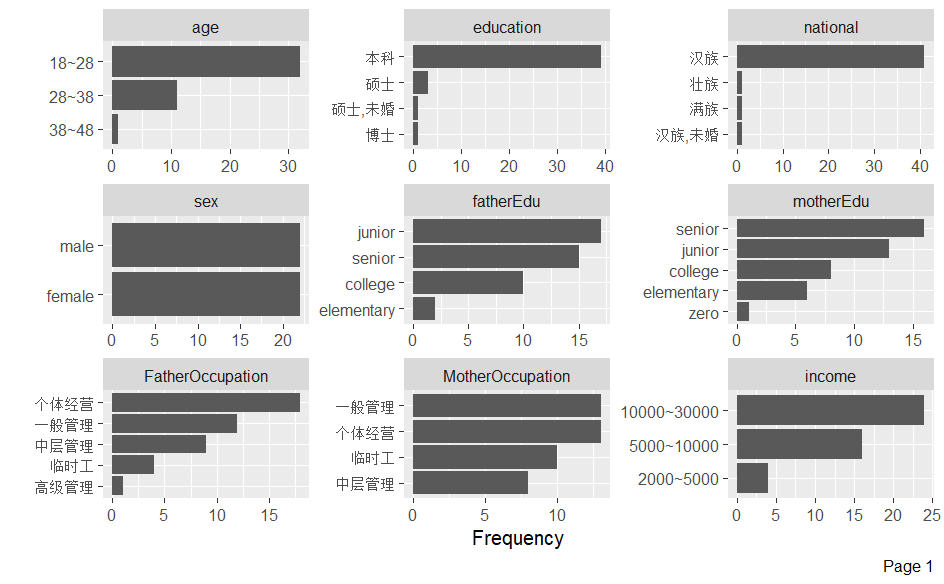

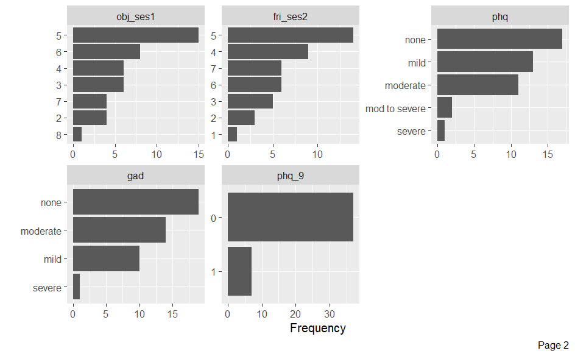

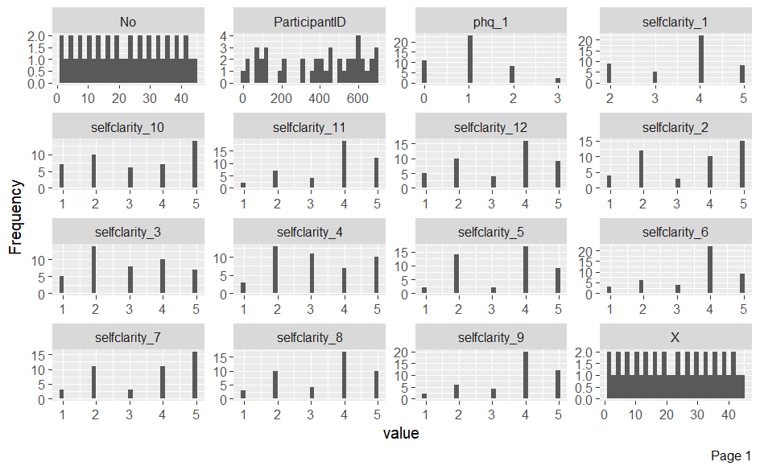

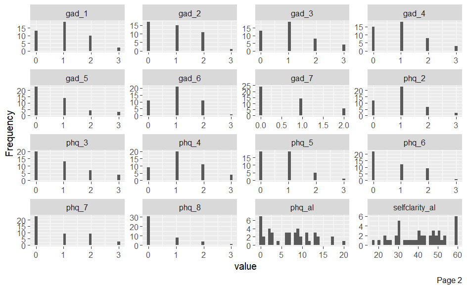

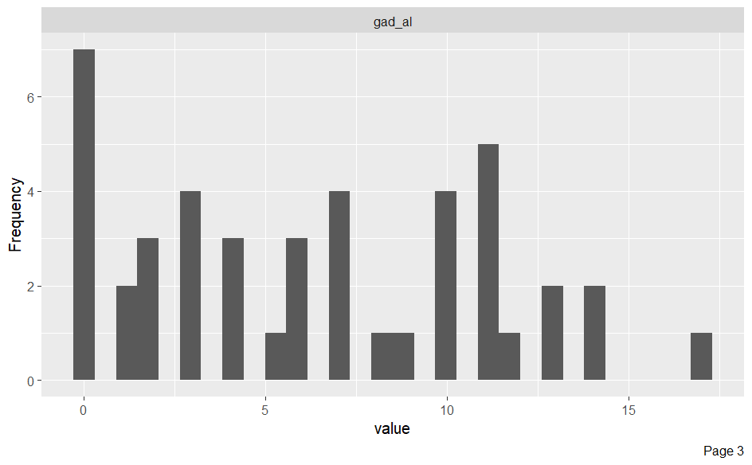

```r
NA
```